# Untitled

# 6.34 mse ad smaller estimator

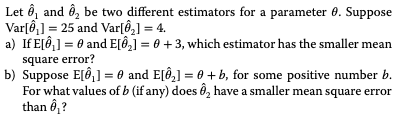

### a)

find mindst mse, var + bias^2

udregn bias

$$B(\hat \theta_1) = \theta - \theta =0 \\
MSE(\hat \theta_1) = 25$$
$$B(\hat \theta_2) = \theta + 3 - \theta = 3 \\
MSE(\hat \theta_1) = 4 + 3^2 = 13$$

theta2 er er med mindst fejl.

### b)

Her skal vi isoler b

$$25 > 4+b^2\longrightarrow \\
21>b^2 \longrightarrow \\
0\le b\le\sqrt(21)$$

# random opgave

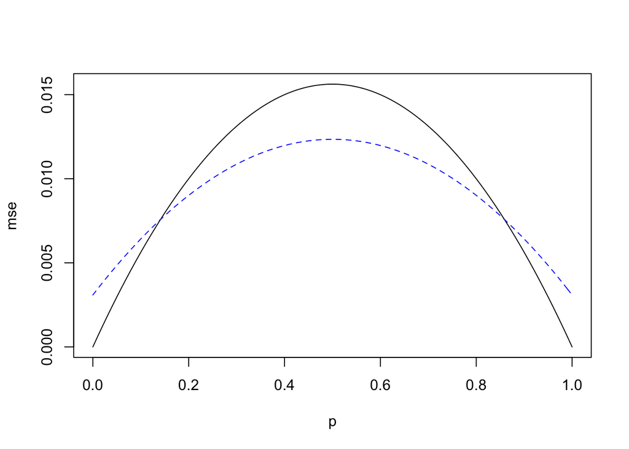

```r
n <- 16
curve(x*(1-x)/n, from = 0,
      to = 1,
      xlab = "p",
      ylab = "mse")

curve(n*(1-x)*x/(n+2)^2 + (1-2*x)^2/(n+2)^2, add = TRUE, col = "blue", lty=2)
```

når n er 16 er der en forskel på mse, men jo højere vi kommer op desto mere konvergere den mod den først så clt.

Er den konsisten? betyder at den også konvergere med en hvis sandsynlighed. Brug her proposition 6.3.4

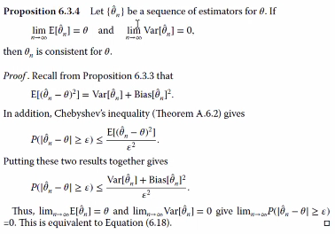

I kapitel 6 som Eskild gennegår ser vi bare desto større n bliver vil vi få den samme fordeling. Husk proposition 6.3.4.

# 5.B: Consider a population that has a normal distribution with mean 𝜇 = 36, standard deviation 𝜎 = 8

## a) The sampling distribution of X for samples of size 200 will have what mean, standard error, and shape

## b) Use R to draw a random sample of size 200 from this population. Conduct EDA on your sample

## c) Compute the bootstrap distribution for your sample, and note the bootstrap mean and standard error.

## d) Compare the bootstrap distribution to the theoretical sampling distribution by creating a table like Table 5.2

## e) Repeat for sample sizes of n = 50 and n = 10. Carefully describe your observations about the effects of sample size on the bootstrap distribution

# 5.9: Consider a population that has a gamma distribution with parameters r = 5, 𝜆 = 1∕4.

## a) Use simulation (with n = 200) to generate an approximate sampling distribution of the mean; plot and describe the distribution.

```r
set.seed(1234)
n = 200
N = 10^4 # 10000 gange
Xbar = numeric(N)

for (i in 1:N){
  sample <- rgamma(n, shape = 5, rate = 1/4)
  Xbar[i] <- mean(sample)
}

mean(Xbar)
```

```
## [1] 20.00137
```

```r
sd(Xbar)
```

```
## [1] 0.6429669
```

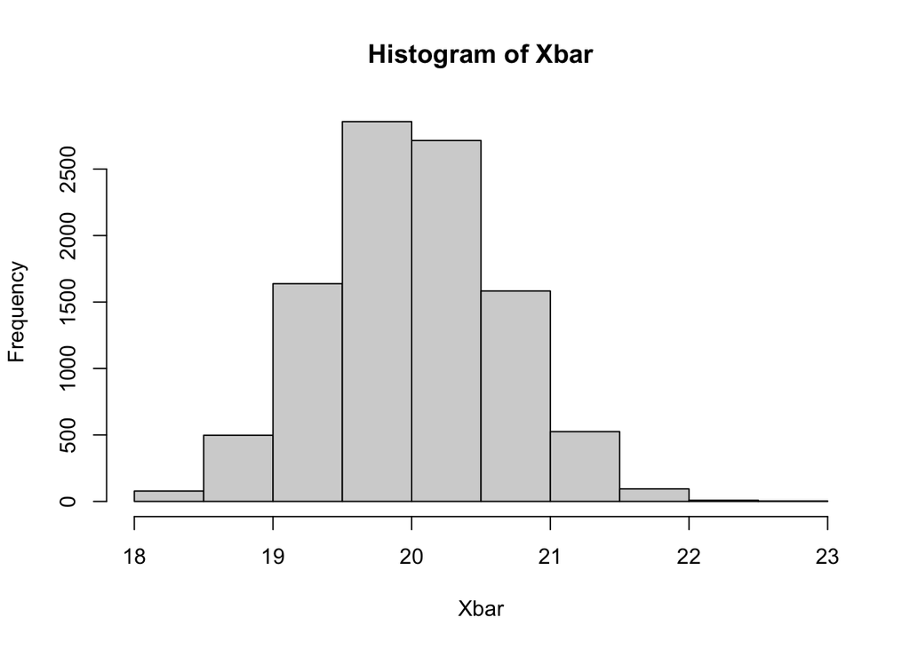

```r
hist(Xbar)
```

Det ser normal fordelt ud. Det er der et theorem der siger.

## b) Now, draw one random sample of size 200 from this population.Create a histogram of your sample, and find the mean and standard deviation

Tag et eksempel

```r
sample <- rgamma(n, 5, 1/4)

mean(sample)
```

```
## [1] 19.8704
```

```r
sd(sample)
```

```
## [1] 9.334515
```

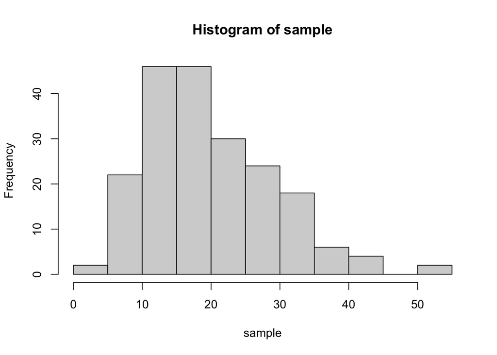

```r
hist(sample)
```

Det ser mere ud til at være en gamem fordeling.

## c) Compute the bootstrap distribution of the mean for your sample, plot it, and note the bootstrap mean and standard error.

```r
N = 10^4

bootstrapXbar = numeric(N)

for (i in 1:N){
  bootstrap <- sample(sample, n, replace = TRUE)
  bootstrapXbar[i] <- mean(bootstrap)
}
mean(bootstrapXbar)
```

```
## [1] 19.86339
```

```r
sd(bootstrapXbar)
```

```
## [1] 0.6519001
```

Vi tager det ud fra en stikprøve og ikke populationen. Det er essens af bootstrap.

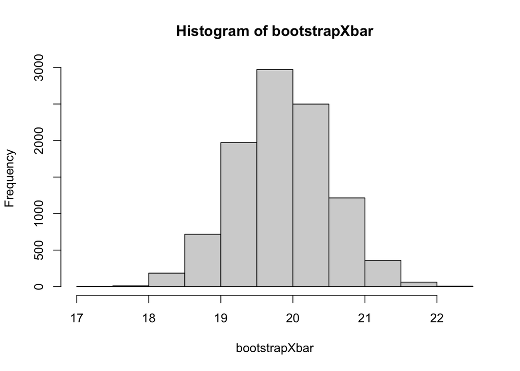

```r
hist(bootstrapXbar)
```

Vi ser det konvergere mod en normal fordeling.

## d) Compare the bootstrap distribution to the approximate theoretical sampling distribution by creating a table like Table 5.2.

```r
pop_mean <- 5/(1/4)
pop_sd <- sqrt(5/(1/4)^2)
tbl <- matrix(c(pop_mean,
                pop_sd,
                mean(Xbar),
                sd(Xbar),
                mean(sample),
                sd(sample),
                mean(bootstrapXbar),
                sd(bootstrapXbar)),
                nrow = 4,
                byrow = TRUE)

rownames(tbl) <- c("Population", "Sampling distribution of Xbar",
                   "Sample", "Bootstrap districution")
colnames(tbl) <- c("mean", "std")
tbl
```

```
##                                   mean       std
## Population                    20.00000 8.9442719
## Sampling distribution of Xbar 20.00137 0.6429669
## Sample                        19.87040 9.3345153
## Bootstrap districution        19.86339 0.6519001
```

sætter middel værdi og st op mod hianden. De minder om hinanden bootstrap, sample og pop.

## e) Repeat (a)–(e) for sample sizes of n = 50 and n = 10. Describe care- fully your observations about the effects of sample size on the bootstrap distribution

# 5.13: The data set FishMercury contains mercury levels (parts per million) for 30 fish caught in lakes in Minnesota.

## a) Create a histogram or boxplot of the data. What do you observe?

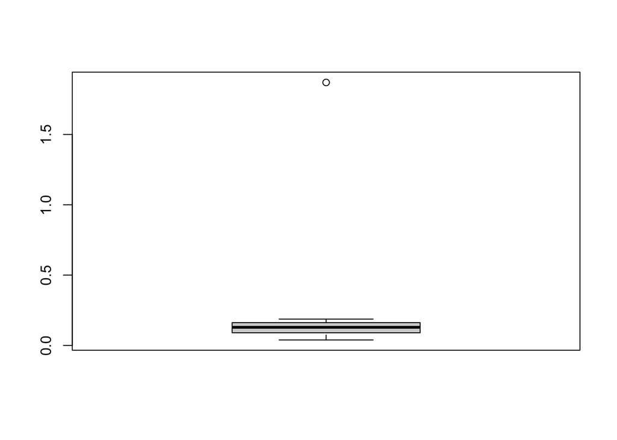

```r
fish <- read.csv("../MatStat-R/data/FishMercury.csv")
boxplot(fish)
```

Der er en outlier.

## b) Bootstrap the mean, and record the bootstrap standard error and the 95% bootstrap percentile interval.

```r
set.seed(1234)
data <- fish$Mercury
nsim <- 1000
xbar <- numeric(nsim)

# sample

for (i in 1:nsim) {
  bootdata <- sample(data, replace = TRUE)
  xbar[i] <- mean(bootdata)
}

mean(xbar)
```

```
## [1] 0.1801634
```

```r
sd(xbar)
```

```
## [1] 0.05641116
```

```r
quantile(xbar, probs = c(0.025, 0.975))
```

```
##      2.5%     97.5%
## 0.1130258 0.3058025
```

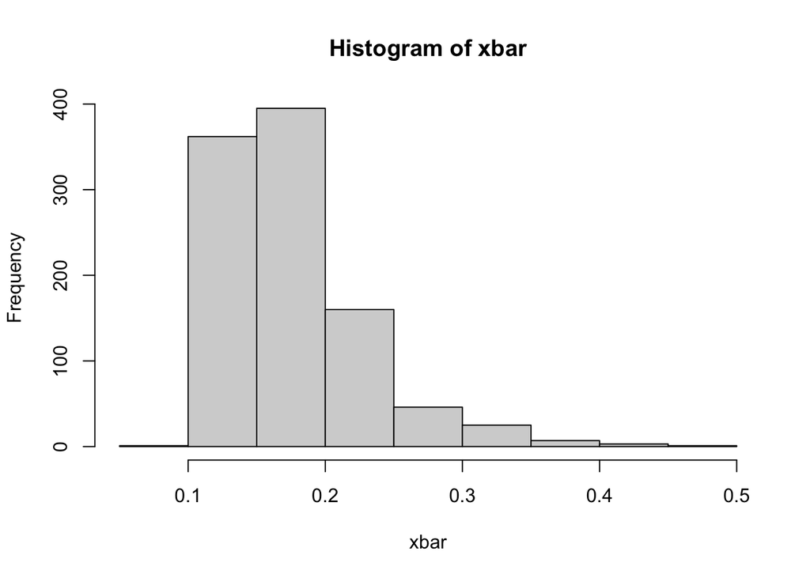

```r
hist(xbar)
```

vi får standard erro, mean og konfidens bånd. Så vi ser den rigtig værdi ligger i intervallet. VI ser også histogrammet

## c) Remove the outlier and bootstrap the mean of the remaining data. Record the bootstrap standard error and the 95% bootstrap percentile interval.

```r
library(tidyverse)
library(magrittr)
```

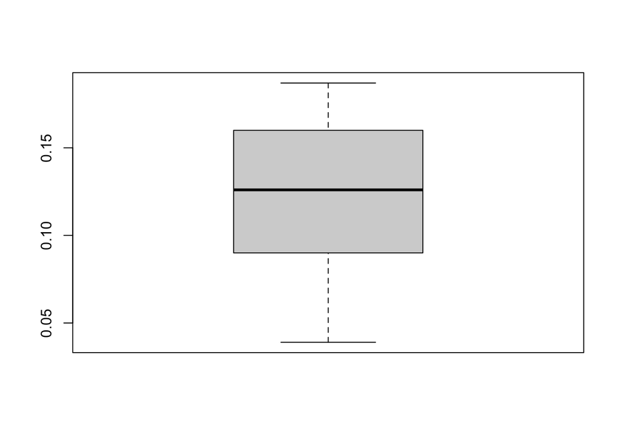

```r
fish_modified <- fish %>% filter(Mercury < max(Mercury))

boxplot(fish_modified)
```

Den ser pæner ud og er mere normal fordelt.

##d) What effect did removing the outlier have on the bootstrap distribu- tion, in particular, the standard error?

```r
set.seed(1234)
data <- fish_modified$Mercury
nsim <- 1000
xbar <- numeric(nsim)

# sample

for (i in 1:nsim) {
  bootdata <- sample(data, replace = TRUE)
  xbar[i] <- mean(bootdata)
}

mean(xbar)
```

```
## [1] 0.1237733
```

```r
sd(xbar)
```

```
## [1] 0.007960822
```

```r
quantile(xbar, probs = c(0.025, 0.975))
```

```
##      2.5%     97.5%
## 0.1074103 0.1382103
```

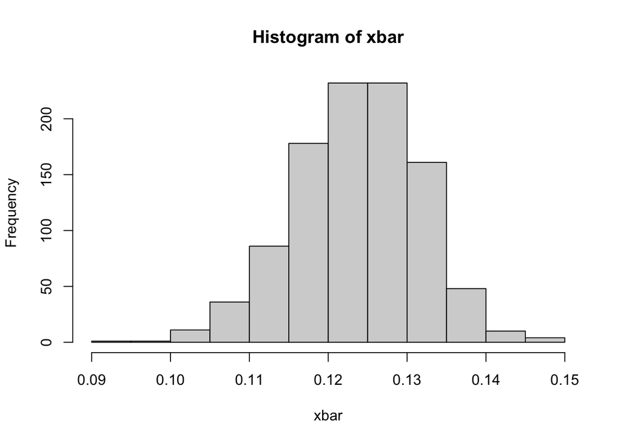

```r
hist(xbar)
```

sd er mindre. Det sammes.

I bootstrop tager man stikprøver af sin stikprøver.

# 6.14

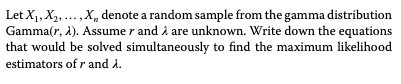

Vi har at $X_1,..,X_n\sim Gamma(r,\lambda)$ med pdf $f(x)=\frac{\lambda^r}{\Gamma(r)}x^{r-1}e^{-\lambda x}$

Vores likelihood funktion er givet ved

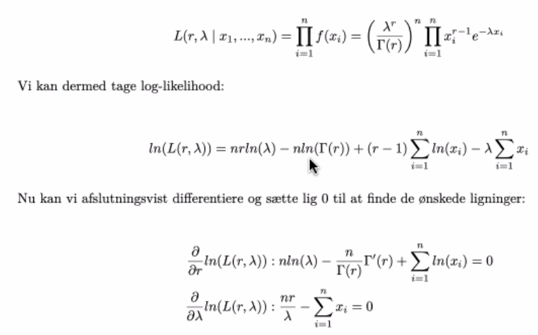

gamme fordeling som vi skal finde estimer r og lambda. vi skal finde log lieklihood estimator. opstil log likelihood. når vi har den skal vi på 158 definere for hver parameter og sæt lig nul og læs ligninsystemet. log likeligho er et produkt af pdf. Summer er letter at arbejde med.